# Keegan’s R Reference Guide

### Boxplot

This function creates a box plot from a vector or data frame Arguments used in box plots: main: Creates title for box plot ylim: Sets y axis extents ylab: Creates label for y axis data: Points to data set to create box plot from

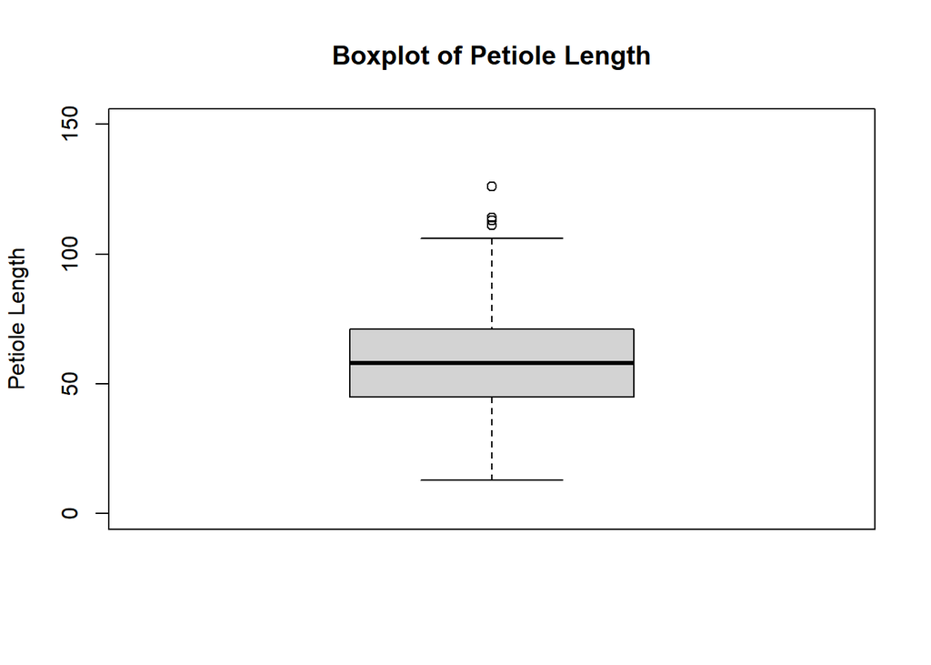

```r
## Here I am first creating a box plot of leaf petiole length. Then I add a title and specify the extents of the Y axis (0-150) and then label the Y axis.
boxplot(ginkgo$petiole_length, main = "Boxplot of Petiole Length", ylim = c(0,150), ylab = "Petiole Length")
```

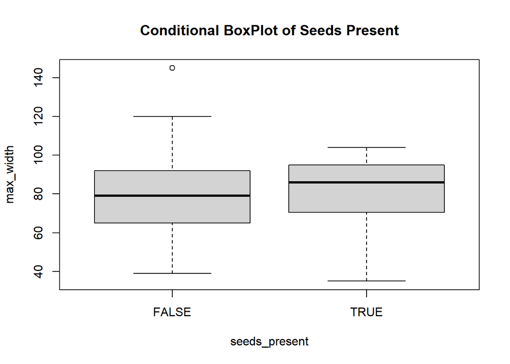

```r
## In the second box plot I am creating a box plot of the leaf max width conditioned on seeds present.
boxplot(max_width ~ seeds_present, data = ginkgo, main = "Conditional BoxPlot of Seeds Present")
```

### Par

This function is used to set or query graphical parameters. In this case we are using it to set the parameters on how to display the four histograms. par(x, y)

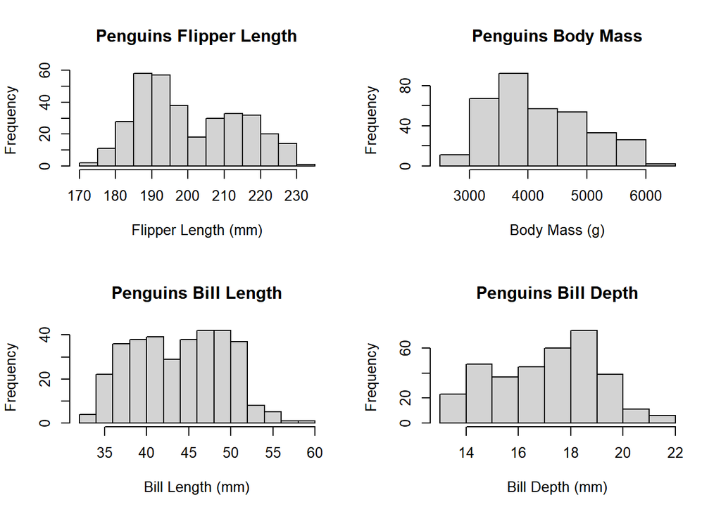

```r
## Here I am creating a 2 by 2 display of my histograms. Hist1 = Flipper Length, Hist2 = Body Mass, Hist3 = Bill Length, Hist4 = Bill Depth
par(mfrow = c(2, 2))
hist(penguins$flipper_length_mm, xlab = 'Flipper Length (mm)', main = "Penguins Flipper Length")
hist(penguins$body_mass_g, xlab = 'Body Mass (g)', main = "Penguins Body Mass")
hist(penguins$bill_length_mm, xlab = 'Bill Length (mm)', main = "Penguins Bill Length")
hist(penguins$bill_depth_mm, xlab = 'Bill Depth (mm)', main = "Penguins Bill Depth")
```

## Distribution Funtions

### dnorm

This function returns the probability density function of a normal distribution using a random variable (x), population mean and population standard deviation. dnorm(x, mean, sd)

```r
## x = 0, mean = 0, sd = 1
dnorm(0, 0, 1)
```

```
## [1] 0.3989423
```

### pnorm

This function returns the cumulative density function of a normal distribution using a random variable (x), population mean and population standard deviation. pnorm(x, mean, sd)

```r
## x = 3, mean = 4, sd = 2
pnorm(3, 4, 2)
```

```
## [1] 0.3085375
```

### qnorm

This function returns the inverse cumulative density function of a normal distribution using a random variable (x), population mean and population standard deviation. qnorm(x, mean, sd)

```r
## x = .99, mean = 0, sd = 1
qnorm(.99, 0, 1)
```

```
## [1] 2.326348
```

### dbinom

This function returns the probability density function of a binomial distribution using a random variable (x), size and probability of success. pnorm(x, size, success)

```r
## x = 3, size = 4, success = 0.25
dbinom(3, 4, 0.25)
```

```
## [1] 0.046875
```

### pbinom

This function returns the cumulative density function of a binomial distribution using a random variable (x), size and probability of success. pnorm(x, size, success)

```r
## x = 3, size = 4, success = 0.25
pbinom(3, 4, 0.25)
```

```
## [1] 0.9960938
```

### qbinom

This function returns the inverse cumulative density function of a binomial distribution using a random variable (x), size and probability of success. pnorm(x, size, success)

```r
## x = 0.5, size = 50, success = 0.5
qbinom(0.5, 50, 0.5)
```

```
## [1] 25
```